# Presentation_Workbook

# FB Data Challenge Workbook

Here is a rough draft of my final pitch, where I used ggplot2 and tidyverse packages to gain a better understanding of the data I worked with and potential visualization options.

## Overall Recommendation

### Part A) Movies or TV Shows?

Clean the data.

```r
titles_yoy <- read.csv("titles_yoy_growth.csv", na.strings = c("NULL"))
titles_yoy$movie_change[is.na(titles_yoy$movie_change)] <- 0
titles_yoy$tv_change[is.na(titles_yoy$tv_change)] <- 0
titles_yoy
```

| date_added_year | movie_count | movie_change | tv_count | tv_change |
| --- | --- | --- | --- | --- |
| 2008 | 1 | 0 | 1 | 0 |
| 2009 | 2 | 1 | 0 | -1 |
| 2010 | 1 | -1 | 0 | 0 |
| 2011 | 13 | 12 | 0 | 0 |
| 2012 | 3 | -10 | 0 | 0 |
| 2013 | 6 | 3 | 5 | 5 |
| 2014 | 19 | 13 | 6 | 1 |
| 2015 | 58 | 39 | 30 | 24 |
| 2016 | 258 | 200 | 185 | 155 |
| 2017 | 864 | 606 | 361 | 176 |

[output cut: 4 more lines]

```r
#write.table(titles_yoy, file = "titles_yoy3.csv", sep = ",", dec = " ", row.names = FALSE)
```

Title Count vs Year Chart

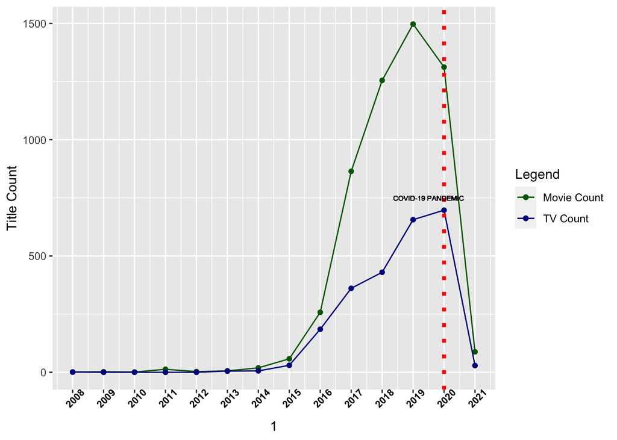

```r
colors <- c("Movie Count" = "darkgreen", "TV Count" = "darkblue")
ggplot(data = titles_yoy, aes(x = date_added_year)) +
           geom_line(aes(y = movie_count, color = "Movie Count")) +
           geom_point(aes(y = movie_count, color = "Movie Count")) +
           geom_line(aes(y = tv_count, color = "TV Count")) +
           geom_point(aes(y = tv_count, color = "TV Count")) +
           labs(x = "Date Added Year", y = "Title Count", color = "Legend") +
           scale_color_manual(values = colors) +
           theme(axis.text.x = element_text(face="bold", color="black",
           size=8, angle=45)) + scale_x_continuous(breaks = seq(2008,2021), 1) +
           geom_vline(xintercept = 2020, linetype = "dotted", size = 1.5, color = "red")+ geom_text(aes(x = 2019.5, y = 750, label = "COVID-19 PANDEMIC"), color =  "black", size = 2)
```

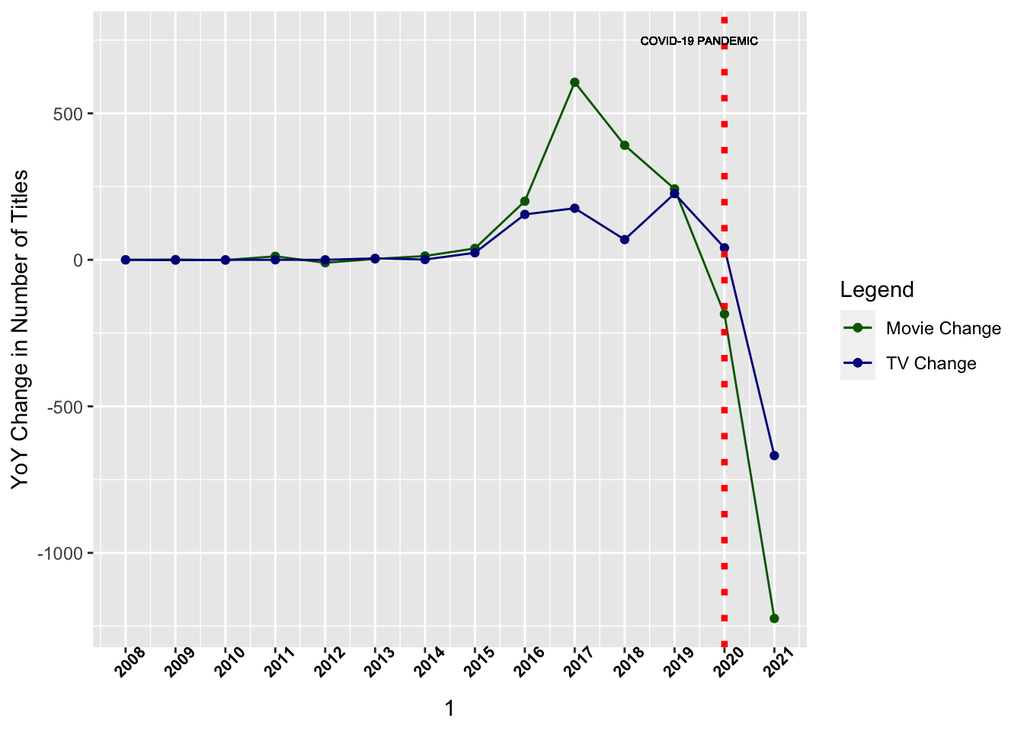

```r
colors <- c("Movie Change" = "darkgreen", "TV Change" = "darkblue")
ggplot(data = titles_yoy, aes(x = date_added_year)) +
           geom_line(aes(y = movie_change, color = "Movie Change")) +
           geom_point(aes(y = movie_change, color = "Movie Change")) +
           geom_line(aes(y = tv_change, color = "TV Change")) +
           geom_point(aes(y = tv_change, color = "TV Change")) +
           labs(x = "Date Added Year", y = "YoY Change in Number of Titles", color = "Legend") +
           scale_color_manual(values = colors) +
           theme(axis.text.x = element_text(face="bold", color="black",
           size=8, angle=45)) + scale_x_continuous(breaks = seq(2008,2021), 1) +
           geom_vline(xintercept = 2020, linetype = "dotted", size = 1.5, color = "red")+ geom_text(aes(x = 2019.5, y = 750, label = "COVID-19 PANDEMIC"), color =  "black", size = 2)
```

Movies have more longevity within the business and seem to have a much higher growth rate from 2015-2019, but started experiencing a decline pre-pandemic. TV Shows were expercincing steady growth during that period as well, but at much lower rates.

There are two ways to interpret these numbers given the basic data we have: a) we can assume the availability of titles correlate to Netflix responding to viewership or user demand b) investment in titles is based off of where Netflix feels it needs to grow in either due to competitors, internal finances, or something else (much of that data is private).

Given Zuckflix’s limited budget, the decision is do we want to invest in areas where Netflix/other competitors are already established because we assume viewership is guiding their investment OR do we want to not subject ourselves to that competition and invest in another space but with the knowledge that we will have less of an idea as to what user engagement will look like.

*Genre Recommendation: TV Shows*

### PART B) Genre and User Rating

#### Genre

```r
genre_count <- read.csv("genre_count.csv")

#ggplot(data = genre_count, aes(x = reorder(genre, count))) + geom_col(aes(y = count), fill = "lightblue") + theme(axis.text.x = element_text(face="bold", color="black", size=8, angle=45, vjust = 0.95, hjust = 1)) + labs(x = "Genre", y = "Overall Title Count")
```

#### User Rating

```r
genre_user_rating <- read.csv("genre_user_rating.csv")

#ggplot(data = genre_user_rating, aes(x = reorder(genre, avg_user_rating))) + geom_col(aes(y = avg_user_rating), fill = "lightgreen") + theme(axis.text.x = element_text(face="bold", color="black", size=8, angle=45, vjust = 0.95, hjust = 1)) + labs(x = "Genre", y = "Average User Rating") + coord_cartesian(ylim = c(7,8.5))
```

#### Overlap

Follow up question - where is there overlap?

```r
inner_join(genre_count,genre_user_rating, by = c("genre" = "genre"))
```

| genre | count | avg_user_rating |
| --- | --- | --- |
| TV Dramas | 704 | 7.26 |
| Crime TV Shows | 427 | 7.34 |
| Docuseries | 353 | 7.40 |
| British TV Shows | 232 | 7.34 |

*Genre recommendation: Docuseries and TV Dramas*

#### New Genre Analysis

Instead, we can look at how each genre fares in terms of title count and user rating all in the same chart. However, this makes it a bit difficult to determine how much weight to give to each dimension.

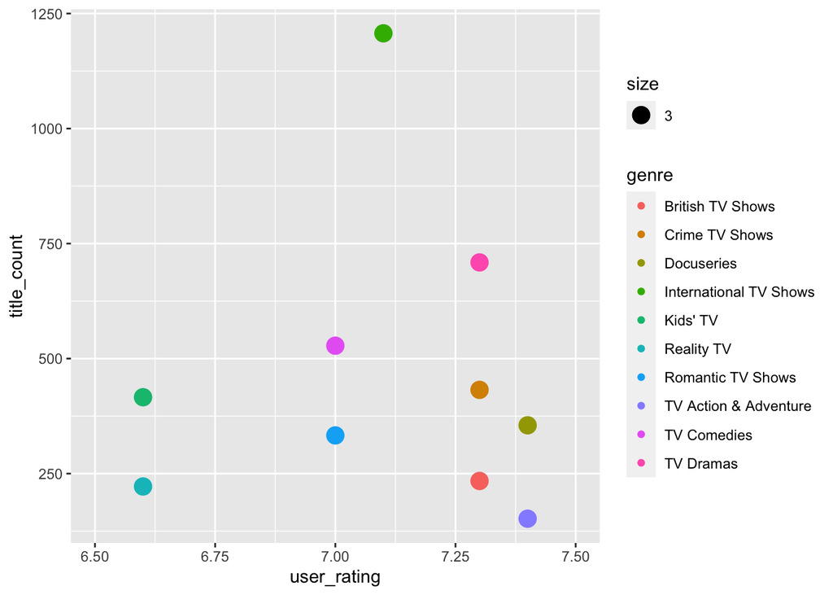

```r
# scatterplot
scatter_genre <- read.csv("scatter_genre.csv")

ggplot(data = scatter_genre, aes(x=user_rating, y=title_count)) + geom_point(aes(color = genre, size = 3)) + xlim(6.5,7.5)
```

A better way to visualize this in Tableau would be a diverging bar chart, which can be seen in the slide deck.

```r
scatter_genre_user <- read.csv("scatter_genre_user.csv")
scatter_genre_user
```

| genre | user_rating | title_count |
| --- | --- | --- |
| Classic & Cult TV | 8.2 | 28 |
| Anime Series | 7.5 | 151 |
| Docuseries | 7.4 | 355 |
| Science & Nature TV | 7.4 | 86 |
| TV Action & Adventure | 7.4 | 152 |
| British TV Shows | 7.3 | 234 |
| Crime TV Shows | 7.3 | 432 |
| TV Dramas | 7.3 | 709 |
| TV Sci-Fi & Fantasy | 7.3 | 78 |
| TV Thrillers | 7.2 | 51 |

```r
# diverging bar chart
inner_join(scatter_genre, scatter_genre_user, by = c("genre" = "genre", "user_rating" = "user_rating", "title_count" = "title_count") )
```

| genre | title_count | user_rating |
| --- | --- | --- |
| TV Dramas | 709 | 7.3 |
| Crime TV Shows | 432 | 7.3 |
| Docuseries | 355 | 7.4 |
| British TV Shows | 234 | 7.3 |
| TV Action & Adventure | 152 | 7.4 |

### Part C) Maturity Rating and Duration

This part was largely edited in Tableau.

*Maturity Rating Recommendation: TV-MA or TV-14*

#### Duration

In order to quickly determine the number of seasons we should recommend per title, we can look at the average number of seasons per genre-rating combination. From this we can suggest the initial anticipate duration of the title should be between 1-2 seasons.

```r
duration_genre <- read.csv("duration_genre.csv")
duration_genre
```

| genre_rating | avg_num_seasons |
| --- | --- |
| Docuseries TV-14 | 1.22 |
| Docuseries TV-MA | 1.45 |
| TV Dramas TV-14 | 1.96 |
| TV Dramas TV-MA | 1.77 |

*Duration Recommendation: 1-2 seasons*

## Country Specific Recommendation

### Choosing a Country

What are we optimizing for?

1. *Facebook’s main source of revenue: ads*. “… while nearly 60% of its daily active users live outside North America and Europe, those users only account for about one-quarter of Facebook’s total revenues”. Thus, ‘Zuckflix’ should be looking to invest in an emerging market outside of the West that has the potential to monetize content, i.e. link ‘ZuckFlix’ titles to existing FB products and ad revenue.
2. India is one of the largest emerging markets according to Goldman Sach’s 2021 EME Report. "…The increased digitalization and internet adoption is *benefitting new-age companies operating in the fields of technology*, communication services and online services.
3. And, “*Southern Asia has over 1.126 billion users that are still unconnected*, making it a top emerging market.” Given Facebook’s (and other tech companies) shift to investing in low bandwith markets, India is a prime country to look at.
4. *India has Facebook’s largest existing user base* (330 mil), meaning it is already established within in the region which will facilitate marketing and connections to ad revenue.
5. *India is not within Netflix’s [top ten leading markets] (https://www.statista.com/statistics/499844/netflix-markets-penetration/)* (by number of subscribers) which decreases competition, although Amazon Prime Video has had increasingly high market penetration in the region.

### Quantifying India’s Market Potential

#### Mobile vs Broadband

While we know that India is a top emerging market, we need to understand the existing landscape in order to determine the best market entry strategy. To start, we can look at broadband vs mobile usage over the years to determine how our users will access our product. [source](https://data.worldbank.org/indicator/IT.CEL.SETS?end=2018&locations=IN&start=1990&view=chart)

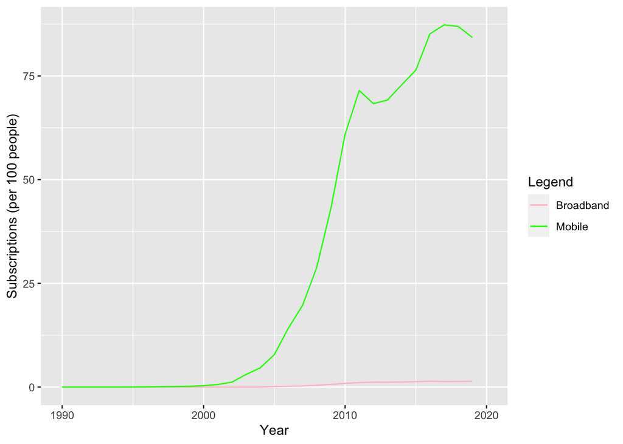

```r
# broadband subscriptions (per 100 ppl)
broadband <- read.csv("broadband_sub.csv")
broadband <- broadband %>% filter(Country.Name == "India")
broadband <- broadband %>% pivot_longer(cols = starts_with("X"), names_to = "year", values_to = "broadband_sub")
broadband <- broadband[,5:6]
broadband$year <- substring(broadband$year, 2, length(broadband$year))
broadband$year <- as.integer(broadband$year)

# mobile subscriptions (per 100 ppl)
mobile <- read.csv("mobile_subww.csv")
mobile <- mobile %>% filter(Country.Name == "India")
mobile <- mobile %>% pivot_longer(cols = starts_with("X"), names_to = "year", values_to = "mobile_sub")
mobile <- mobile[,5:6]
mobile$year <- substring(mobile$year, 2, length(mobile$year))
mobile$year <- as.integer(mobile$year)

# look at both overlayed
broad_mobile <- inner_join(broadband, mobile, by = c("year" = "year"))
broad_mobile$broadband_sub[is.na(broad_mobile$broadband_sub)] <- 0
broad_mobile$mobile_sub[is.na(broad_mobile$mobile_sub)] <- 0
broad_mobile <- broad_mobile[-nrow(broad_mobile),]

# write to csv
#write.table(broad_mobile, file = "broad_mobile_tableau.csv", sep = ",", dec = " ", row.names = FALSE)

# graph
colors <- c("Broadband" = "pink", "Mobile" = "green")
ggplot(data = broad_mobile, aes(x=year)) + geom_line(aes(y=broadband_sub, color = "Broadband")) + geom_line(aes(y=mobile_sub, color = "Mobile")) + labs(x = "Year", y = "Subscriptions (per 100 people)", color = "Legend") + scale_color_manual(values = colors) + xlim(1990,2020)
```

We can see that mobile subscriptions far outnumber broadband subscriptions, which means we should be optimizing for content that will perform best on smaller screens and mobile devices.

*User Access Touchpoint: Mobile*

#### India Age Demographics

Next, let’s take a look at India’s age demographic breakdown to determine what content rating level would best suit the largest audience. *[source1](https://www.statista.com/statistics/271315/age-distribution-in-india/)* [source2](https://databank.worldbank.org/source/world-development-indicators#)

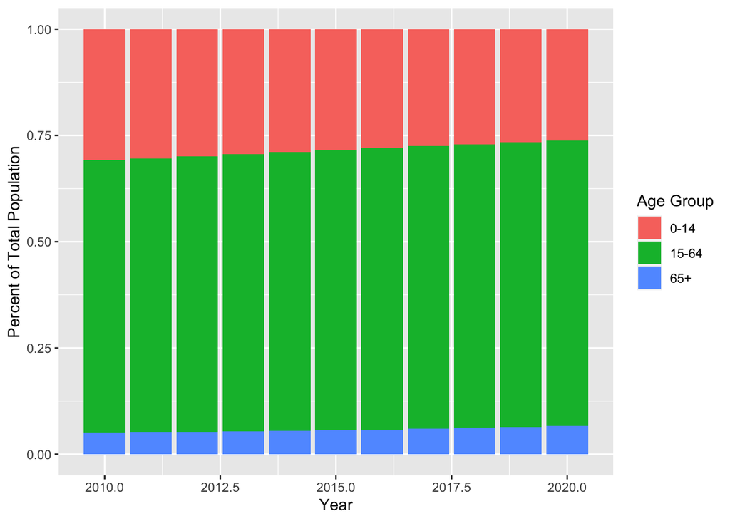

```r
india_age <- read.csv("india_age_breakdown.csv")
colnames(india_age) <- c("year", "0-14", "15-64", "65+")
india_age <- pivot_longer(india_age, cols = c("0-14", "15-64", "65+"), names_to = "age_group", values_to = "population_perc")
#india_age$population_perc <- paste(india_age$population_perc, "%")

#write.table(india_age, file = "india_age_tableau_3.csv", sep = ",", dec = ".", row.names = FALSE)


ggplot(data = india_age, aes(x = year, y = population_perc, fill = age_group)) +geom_bar(position = "fill", stat = "identity" ) +labs(x="Year", y = "Percent of Total Population", fill = "Age Group")
```

*Content Rating Recommendation: Adult Content (i.e. TV-14/PG-13 and up)*

#### Language Breakdown

Because India is a multilingual country, content reusability across a vareity of different langauges and cultures will be important; namely, the cost of adding a subtitle is lower than the cost of voice-overs or reproducing the show entirely, so we should produce the original content in such a way that will cater to the widest audience.

```r
languages <- read.csv("india_language.csv")
languages <- languages %>% top_n(10)
```

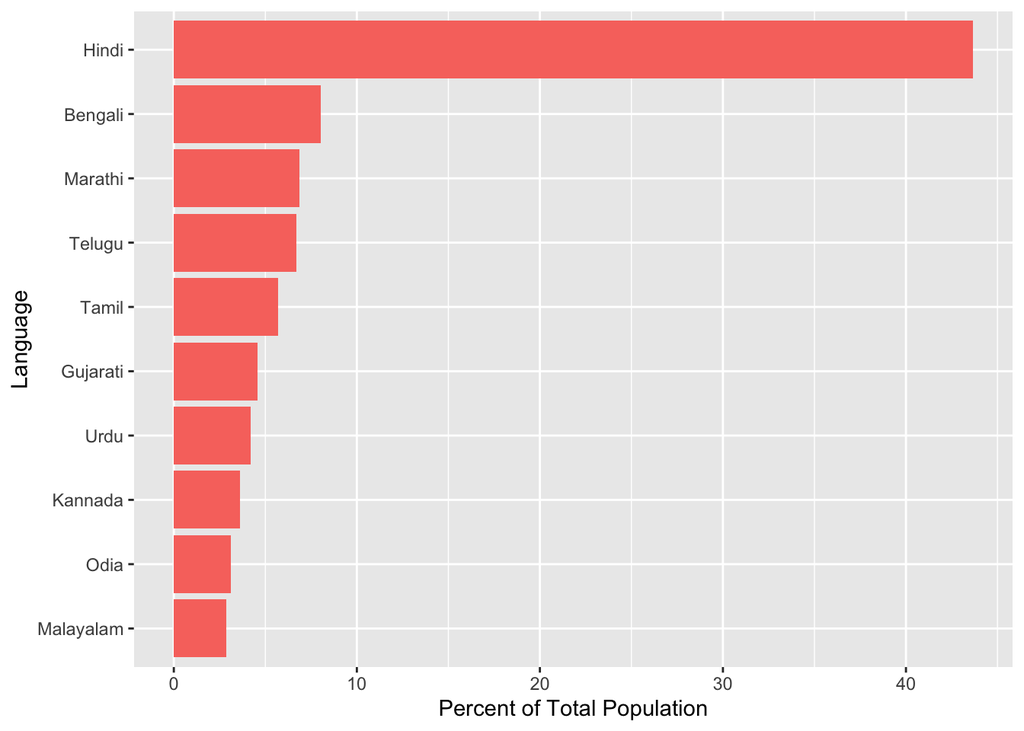

```r
#write.table(languages, file = "languages_tableau.csv", sep = ",", dec = " ", row.names = FALSE)

ggplot(data = languages, aes(x=reorder(Language, Percent))) + geom_col(aes(y=Percent, fill = "orange")) + coord_flip() + labs(x = "Language", y = "Percent of Total Population") + theme(legend.position = "none")
```

Alternatively, we can rank languages in terms of their respective film industry’s box office contributions.

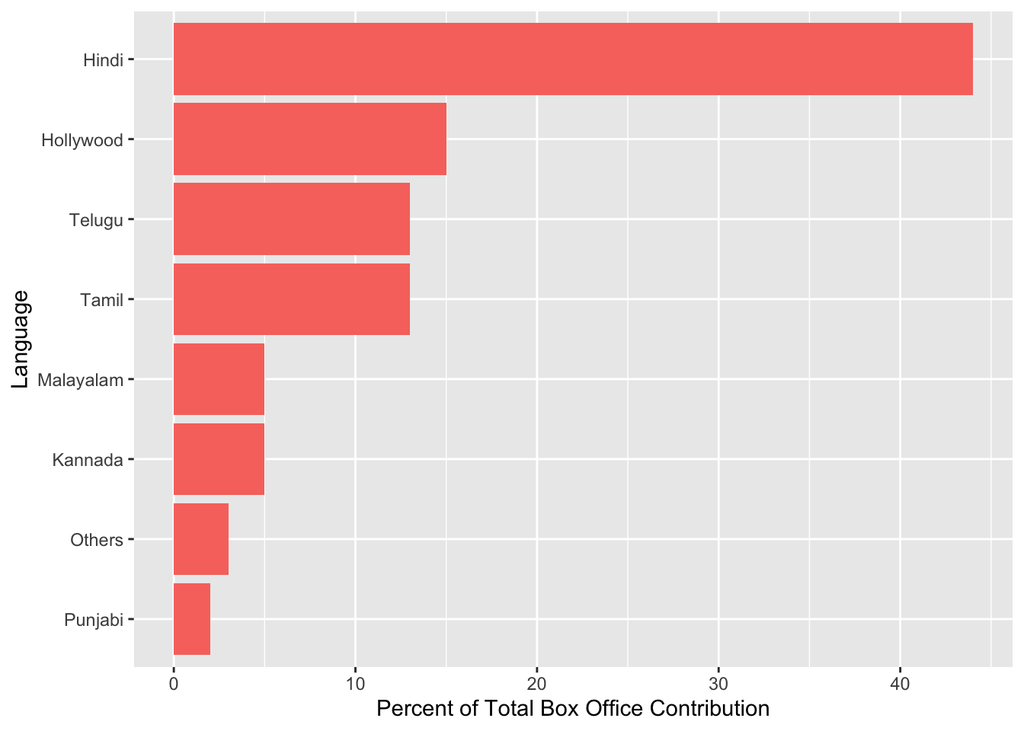

```r
box_office <- read.csv("box_officed.csv")
ggplot(data = box_office, aes(x=reorder(Language, Percent))) + geom_col(aes(y=Percent, fill = "orange")) + coord_flip() + labs(x = "Language", y = "Percent of Total Box Office Contribution") + theme(legend.position = "none")
```

```r
write.table(box_office, file = "box_office.csv", sep = ",", dec = ".", row.names = FALSE)
```

```r
india_combined <- inner_join(languages, box_office, by = c("Language" = "Language"))
india_combined$Percent.x <- round(india_combined$Percent.x,0)
colnames(india_combined) <- c("Language", "Total Population", "Percent of Total Population", "Percent of Box Office Contribution")
india_combined
```

| Language | Total Population | Percent of Total Population | Percent of Box Office Contribution | None |
| --- | --- | --- | --- | --- |
| Hindi | 528347193 | 44 | 44 | NA |
| Telugu | 81127740 | 7 | 13 | NA |
| Tamil | 69026881 | 6 | 13 | NA |
| Kannada | 43706512 | 4 | 5 | NA |
| Malayalam | 34838819 | 3 | 5 | NA |

```r
write.table(india_combined, file = "india_combined.csv", sep = ",", dec = ".", row.names = FALSE)
```

*Language Recommendation: Hindi (Bollywood*

### Content Recommendation

#### Movie or TV Show?

There are 990 distinct titles.

Let’s look at the title breakdown by title type. Unsurprisingly, we see that there are more movies rather than TV shows, which makes sense given that the Bollywood film industry is worth over a couple billion dollars and India produces the most films out of any country.

```r
title_type <- read.csv("india_titletype.csv")
title_type
```

| num_movies | num_shows |
| --- | --- |
| 915 | 75 |

#### Genre

We can look at genres filtered by country and the above maturity rating. It is important to note that in this dataset, Indian movies are filtered by American TV status (TV-14, TV-MA) as well as Movie status (PG-13, R) so both ratings are taken into account when conducting this genre-based analysis.

This part was largely done in Tableau.

*Genre Recommendation: Comedies and Dramas* (Indian staples!)